# Analisando amostras de dados com intervalos de confiança

Veruska Santos

17 de maio de 2018

Este relatório é uma versão editada da resposta do exercício proposto pelo Wikimedia, disponível no GitHub¹.

## 1. Objetivo

Neste relatório, analisaremos os dados de busca e navegação de projetos do Wikimedia e tentaremos responder as seguintes perguntas, separadamente:

1. Qual é a taxa de cliques geral diária? Como isso varia entre os grupos?
2. Quais resultados as pessoas tendem a tentar primeiro? Como isso muda no dia-a-dia?
3. Qual é a taxa de resultados zero no geral? Como isso varia entre os grupos?

Como a Wikimedia disponibilizou apenas uma amostra dos dados, ou seja, um conjunto de buscas de alguns usuários, utilizaremos de visualizações e análises estatísticas para inferir resultados da população inteira, isto é, de todos os usuários da Wikimedia, a partir dos resultados obtidos da amostra disponibilizada.

## 2. Background

Iremos utilizar a técnica de bootstrap, para inferir resultados sobre o conjuntos de todos os usuários da wikimedia, com 95% de confiança. O **bootstrap** consiste em, dado uma amostra de dados de tamanho n, extrair várias amostras dessa amostra, também com tamanho n, ou seja, com repetição dos dados. Então, para cada amostra extraída, a mesma estatística desejada é calculada, para verificar como é a sua variação.

Após o bootstrapping, o **intervalo de confiança** pode ser gerado, que nos dá o intervalo onde a nossa estatística desejada está, com 95% de confiança, no nosso caso. Quando se está analisando relação entre dois grupos, por exemplo, os valores mínimo e máximo do intervalo têm um significado:

- se ambos os valores são positivos significa que o primeiro grupo analisado tem uma relação **maior** que o segundo grupo. Ex: [20, 29];
- se os valores são negativos significa que o primeiro grupo analisado tem uma relação **menor** que o segundo grupo. Ex: [-8, -1];
- se os valores são positivos e negativos e o intervalo é muito grande, então não há relação entre os grupos. Ex: [-59, 71];
- caso contrário, não há diferença significativa entre os grupos analisados. Ex: [-0.02, 0.1].

## 3. Configurações

Abaixo estão as dependências necessárias para reproduzir este relatório.

```r
library(tidyverse)
library(here)
library(lubridate)
library(boot)
```

O objeto principal da análise são as buscas e a navegação depois da busca. Criamos esses dados a partir dos dados originais da wikimedia em `/data/search_data.csv`.

```r
buscas = read_csv(here::here("data/search_data.csv"))
```

Adicionaremos uma nova variável **date** aos dados, que é a variável session_start_date sem a hora, para facilitar as análises e evitar repetição de código.

```r
buscas <- mutate(buscas, date = date(session_start_date))
```

## 5. Análise dos dados

Agora, utilizaremos de visualizações e inferências para analisar os dados e responder as perguntas já descritas.

### 5.1 Qual é a taxa de cliques geral diária? Como isso varia entre os grupos?

Para responder esta pergunta, iremos usar as variáveis **num_clicks**, **date** e **group** e calcularemos a taxa, que é a soma dos cliques do dia dividido pelo total de buscas do referido dia, ou seja,

**taxa de cliques** = soma dos cliques do dia / total de buscas do dia.

```r
buscas_sem_dia_8 <- buscas %>%
    filter(date != "2016-03-08")
```

No laboratório anterior², conseguimos os seguintes resultados mostrados nos gráficos 5.1.1 e 5.1.2, respectivamente: a taxa de cliques diária geral varia entre aproximadamente 24% e 36% e, comparando por grupos, o grupo *a* apresenta as maiores taxas de cliques em todos os dias analisados em relação ao grupo *b*.

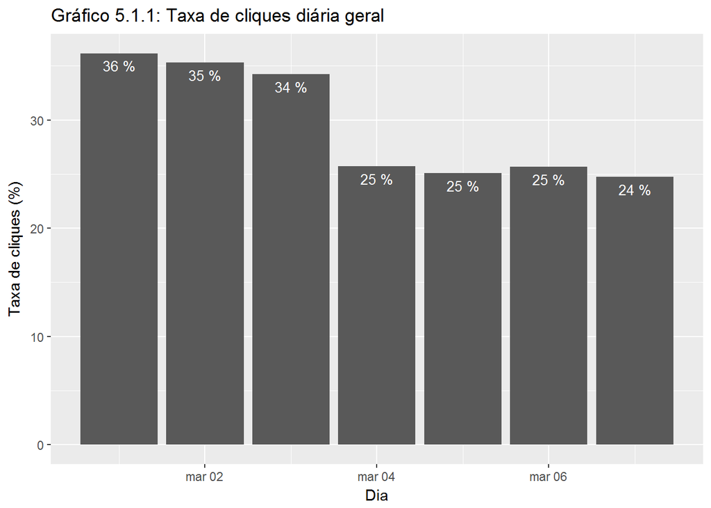

```r
total_cliques <- buscas_sem_dia_8 %>%
    group_by(date) %>%
    summarise(clicks = sum(num_clicks), n = n(), taxa = (clicks/n)*100)

taxa_cliques_total <- total_cliques%>%
    ggplot(aes(x = date, y = taxa)) +
    geom_col(position = "dodge") +
    geom_text(aes(x = date, y = taxa, label=paste(trunc(taxa), "%")), vjust=1.6, color="white", size=3.5) +
    labs(x = "Dia", y = "Taxa de cliques (%)",
         title = "Gráfico 5.1.1: Taxa de cliques diária geral")

print(taxa_cliques_total)
```

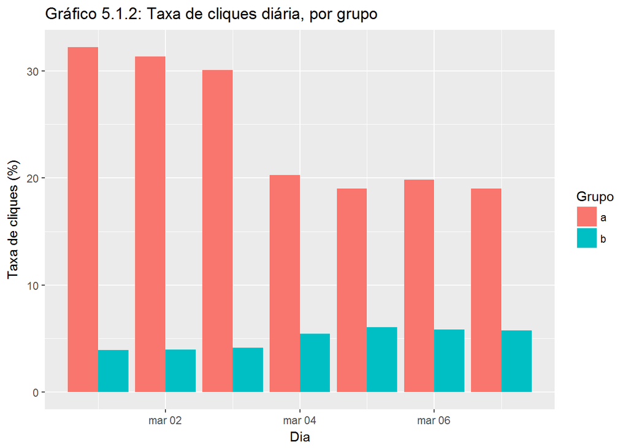

```r
total_buscas_dia <- buscas_sem_dia_8 %>%
    group_by(date) %>%
    count(date)

total_cliques <- buscas_sem_dia_8 %>%
    group_by(date, group) %>%
    summarise(clicks = sum(num_clicks))

merge_cliques_buscas <- merge(total_cliques, total_buscas_dia)

taxa_cliques_grupos <- merge_cliques_buscas %>%
    ggplot(aes(x = date, y = (clicks/n)*100, fill = group)) +
    geom_col(position = "dodge") +
    labs(x = "Dia", y = "Taxa de cliques (%)", fill = "Grupo",
         title = "Gráfico 5.1.2: Taxa de cliques diária, por grupo")

print(taxa_cliques_grupos)
```

Agora, iremos utilizar a técnica de bootstrap e os intervalos de confiança.

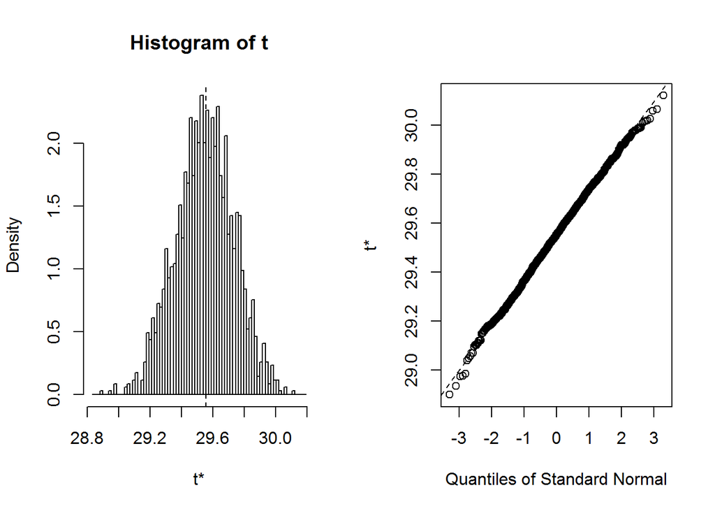

```r
amostra <- buscas_sem_dia_8

calcula_taxa_cliques <- function(dados, indices) {
    media_taxa_cliques <- dados %>%
            slice(indices) %>%  #<- reamostragem
            group_by(date) %>%
            summarise(clicks = sum(num_clicks), n = n(), taxa = (clicks/n)*100) %>%
            pull(taxa) %>%
            mean()

    return(media_taxa_cliques)
}

res.boot <- boot(data = amostra,
                 statistic = calcula_taxa_cliques,
                 R = 2000)  #<- repetição

plot(res.boot)
```

```r
calcula_ci <- function(distribuicao) { #<- função para calcular intervalo de confiança
    return(boot.ci(boot.out = distribuicao, conf = 0.95, type = "basic"))
}

calcula_ci(res.boot)
```

```
## BOOTSTRAP CONFIDENCE INTERVAL CALCULATIONS
## Based on 2000 bootstrap replicates
##
## CALL :
## boot.ci(boot.out = distribuicao, conf = 0.95, type = "basic")
##
## Intervals :
## Level      Basic
## 95%   (29.20, 29.92 )
## Calculations and Intervals on Original Scale
```

Dado o resultado acima, podemos inferir que, a partir desta amostra de dados, a média da taxa geral diária de cliques está entre 29% e 30%, com 95% de confiança.

Abaixo, analisaremos a taxa geral diária de cliques, por grupo.

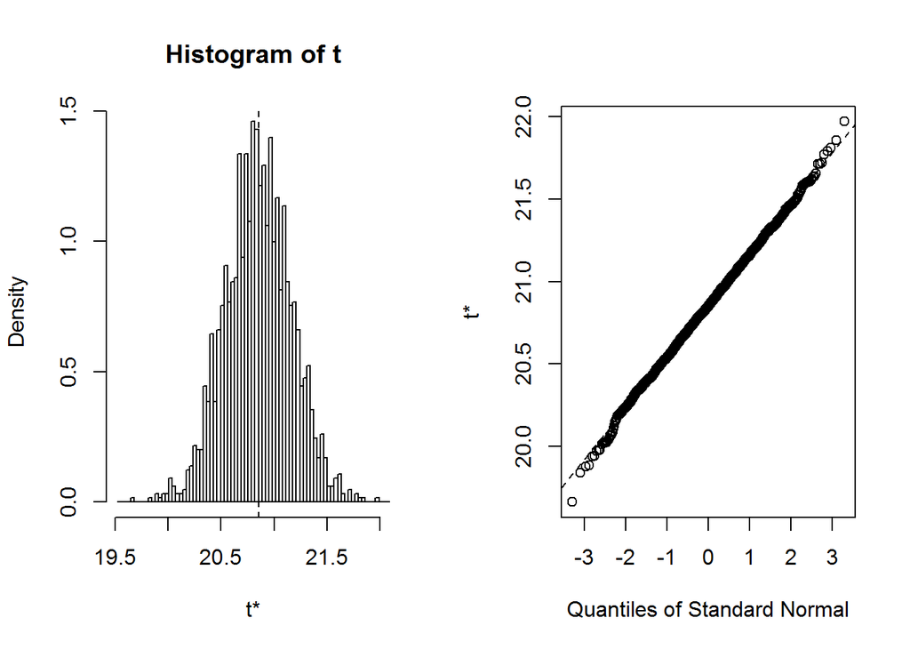

```r
calcula_taxa_cliques <- function(dados, indices) {
    media_taxa_cliques <- dados %>%
            slice(indices) %>%
            group_by(group, date) %>%
            summarise(clicks = sum(num_clicks), n = n(), taxa = (clicks/n)*100) %>%
            summarise(media = mean(taxa)) %>%
            pull(media)

    return(media_taxa_cliques[1] - media_taxa_cliques[2])
}

res.boot <- boot(data = amostra,
                 statistic = calcula_taxa_cliques,
                 R = 2000)
plot(res.boot)
```

```r
calcula_ci(res.boot)
```

```
## BOOTSTRAP CONFIDENCE INTERVAL CALCULATIONS
## Based on 2000 bootstrap replicates
##
## CALL :
## boot.ci(boot.out = distribuicao, conf = 0.95, type = "basic")
##
## Intervals :
## Level      Basic
## 95%   (20.25, 21.46 )
## Calculations and Intervals on Original Scale
```

Como o intervalo de confiança, acima, deu positivo para a diferença da taxa de cliques entre os grupos *a* e *b*, significa que podemos inferir que, a taxa de cliques diária, para o grupo *a*, é sempre maior que a taxa de cliques para o grupo *b*.

### 5.1.1 Como a taxa de cliques geral diária varia entre os grupos A/A?

Uma variação da análise anterior é a análise de como a taxa de cliques geral diária varia entre o grupo *a*, ou seja, iremos comparar metade do grupo a (escolhida aleatoriamente) com a outra metade do próprio grupo *a*.

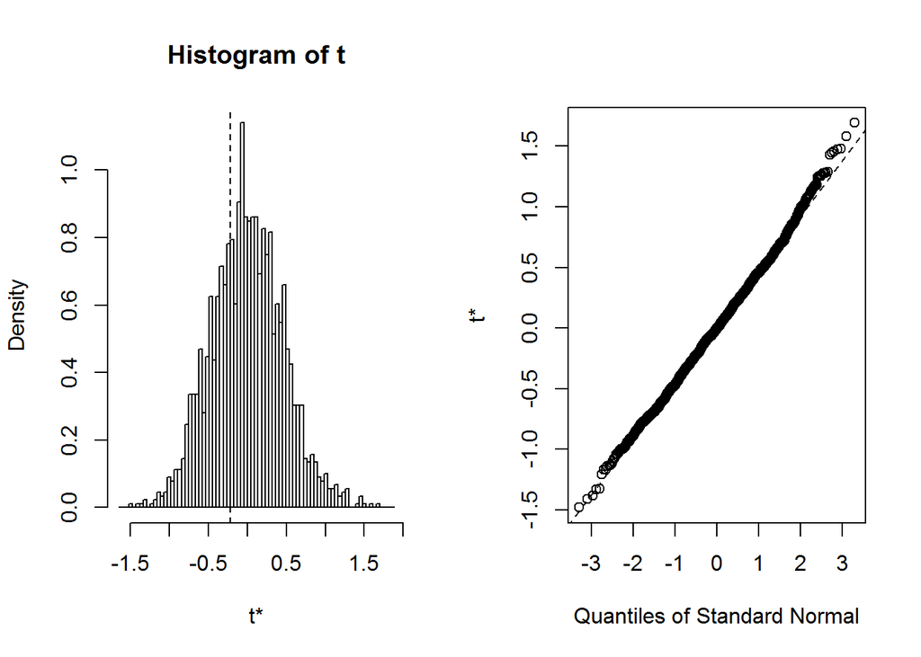

```r
amostra <- buscas %>%
            filter(group == "a")

tamanho_amostra <- amostra %>%
                    summarise(tamanho = n()) %>%
                    pull(tamanho)

calcula_taxa_cliques <- function(dados, indices) {

    dados <- dados %>%
        slice(indices)

    amostra1 <- dados %>%
                slice(1 : (tamanho_amostra/2)) %>%   #<- primeira metade dos dados do grupo a
                mutate(grupo = "a1")

    amostra2 <- dados %>%
                slice(tamanho_amostra/2 + 1: tamanho_amostra) %>%  #<- segunda metade dos dados do grupo a
                mutate(grupo = "a2")

    nova_amostra <- bind_rows(amostra1, amostra2)

    media_taxa_cliques <- nova_amostra %>%
            group_by(grupo, date) %>%
            summarise(clicks = sum(num_clicks), n = n(), taxa = (clicks/n)*100) %>%
            summarise(media = mean(taxa)) %>%
            pull(media)

    return(media_taxa_cliques[1] - media_taxa_cliques[2])
}

res.boot <- boot(data = amostra,
                 statistic = calcula_taxa_cliques,
                 R = 2000)
plot(res.boot)
```

```r
calcula_ci(res.boot)
```

```
## BOOTSTRAP CONFIDENCE INTERVAL CALCULATIONS
## Based on 2000 bootstrap replicates
##
## CALL :
## boot.ci(boot.out = distribuicao, conf = 0.95, type = "basic")
##
## Intervals :
## Level      Basic
## 95%   (-1.4032,  0.4262 )
## Calculations and Intervals on Original Scale
```

Com o resultado acima, confirmamos o esperado: não há diferença na taxa de cliques diárias dentro do grupo *a*, porque o valor 0 está dentro do intervalo de confiança, como explicado na seção 2.

### 5.2 Quais resultados as pessoas tendem a tentar primeiro? Como isso muda no dia-a-dia?

Para responder esta pergunta, iremos usar as variáveis **results**, **first_click** e **date**.

Como para buscas sem resultados, em geral, não há nenhum clique (há 4 exceções nos dados), removeremos as buscas cujo resultado foi zero e não possui valores registrados para o primeiro clique. Assim, filtraremos e analisaremos apenas as buscas que têm 1 ou mais resultados e valores de primeiro clique registrados.

```r
buscas_com_resultado <- buscas %>%
    filter(results > 0, !is.na(first_click))
```

O filtro acima resultou em 33.187 dados que iremos analisar, sendo, 122 destes, buscas cujo índice do primeiro clique é maior que 100. Essas 122 buscas removeremos do gráfico abaixo, para facilitar a visualização da maioria dos dados, mas em seguida, no Gráfico 5.2.2, os mostraremos novamente através do boxplot.

No lab anterior, conseguimos os seguintes resultados mostrados nos gráficos 5.2.1 e 5.2.2, respectivamente. Os usuários tendem, claramente, a clicar no primeiro resultado da busca, depois no segundo e assim, sucessivamente, devido à tendência decrescente exibida no gráfico, o que indica que os algoritmos de rankeamento da plataforma estão adequados. Além disso, não há diferença significativa entre os primeiros cliques dos usuários entre os dias, porque os boxplots (retângulos verdes) parecem apresentar as mesmas características. Exceto no dia 04 (sexta-feira), onde houve mais cliques nos resultados de índices altos, ou seja, há mais pontos, que representam as buscas, na parte superior do gráfico.

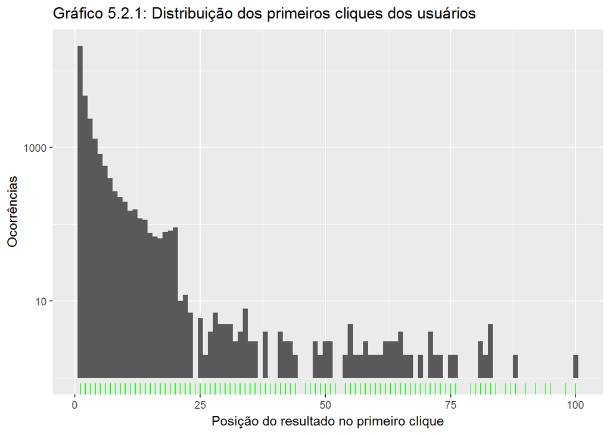

```r
buscas_com_resultado %>%
    filter(first_click <= 100) %>%
    ggplot(aes(x = first_click)) +
    geom_histogram(binwidth = 1) +
    geom_rug(alpha = .7, color = "green") +
    scale_y_log10() +
    labs(x = "Posição do resultado no primeiro clique", y = "Ocorrências",
         title = "Gráfico 5.2.1: Distribuição dos primeiros cliques dos usuários")
```

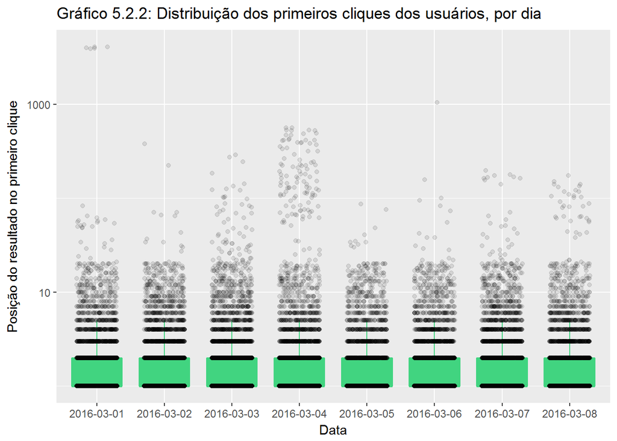

```r
buscas_com_resultado %>%
    ggplot(aes(x = factor(date), y = first_click)) +
    geom_boxplot(outlier.shape=NA, color = "#41d480", fill = "#41d480") +
    geom_jitter(alpha = .1, width = .3) +
    scale_y_log10() +
    labs(x = "Data", y = "Posição do resultado no primeiro clique",
         title = "Gráfico 5.2.2: Distribuição dos primeiros cliques dos usuários, por dia")
```

Faremos novamente reamostragens para inferir resultados, com 95% de confiança, sobre o conjunto de todos os usuários da Wikimedia.

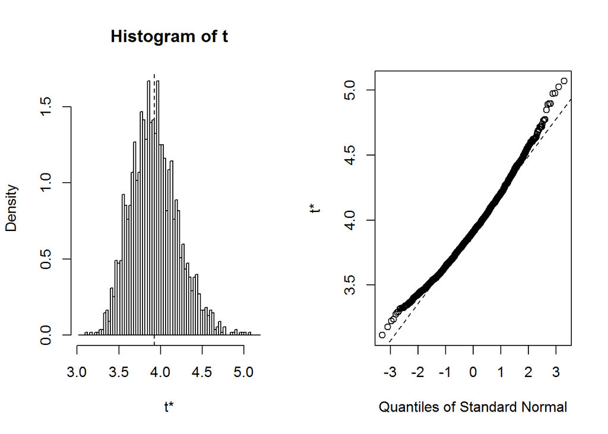

```r
amostra <- buscas_com_resultado

calcula_primeiro_clique <- function(dados, indices) {
    media_primeiro_clique <- dados %>%
            slice(indices) %>%
            pull(first_click) %>%
            mean()

    return(media_primeiro_clique)
}

res.boot <- boot(data = amostra,
                 statistic = calcula_primeiro_clique,
                 R = 2000)
plot(res.boot)
```

```r
calcula_ci(res.boot)
```

```
## BOOTSTRAP CONFIDENCE INTERVAL CALCULATIONS
## Based on 2000 bootstrap replicates
##
## CALL :
## boot.ci(boot.out = distribuicao, conf = 0.95, type = "basic")
##
## Intervals :
## Level      Basic
## 95%   ( 3.297,  4.412 )
## Calculations and Intervals on Original Scale
```

Calculamos a média dos primeiros cliques do usuário e encontramos um intervalo de confiança entre 3 e 5, com 95% de confiança, ou seja, inferimos que os primeiros cliques de todos os usuários são nos primeiros resultados, porque a média deu baixa.

Para ter mais clareza, vejamos a mediana dos primeiros cliques, que é sempre igual a 1, e, portanto, não há intervalo de confiança.

```r
calcula_primeiro_clique <- function(dados, indices) {
    mediana_primeiro_clique <- dados %>%
            slice(indices) %>%
            pull(first_click) %>%
            median()

    return(mediana_primeiro_clique)
}

res.boot <- boot(data = amostra,
                 statistic = calcula_primeiro_clique,
                 R = 2000)
plot(res.boot)
```

```
## [1] "All values of t* are equal to  1"
```

```r
calcula_ci(res.boot)
```

```
## [1] "All values of t are equal to  1 \n Cannot calculate confidence intervals"
```

Agora, verificaremos a preferência dos resultados por dia da semana. Para isso, adicionaremos uma coluna **day**, nos dados, que representa o dia da semana em que a busca foi realizada.

```r
buscas_com_resultado <- mutate(buscas_com_resultado, day = strftime(date, '%A'))
```

[figure not shown]

```r
set.seed(1)

gera_amostra <- function(dia) {
    amostra <- buscas_com_resultado %>%
                    filter(day == dia)
    return(amostra)
}

amostra_domingo <- gera_amostra("domingo")
amostra_segunda <- gera_amostra("segunda-feira")
amostra_terca <- gera_amostra("terça-feira")
amostra_quarta <- gera_amostra("quarta-feira")
amostra_quinta <- gera_amostra("quinta-feira")
amostra_sexta <- gera_amostra("sexta-feira")
amostra_sabado <- gera_amostra("sábado")

calcula_primeiro_clique <- function(dados, indices) {
    media_primeiro_clique <- dados %>%
            slice(indices) %>%
            pull(first_click) %>%
            mean()

    return(media_primeiro_clique)
}

calcula_distribuicao <- function(amostra) {
    distribuicao <- boot(data = amostra,
                 statistic = calcula_primeiro_clique,
                 R = 2000)

    return(distribuicao)
}

distribuicao_domingo <- calcula_distribuicao(amostra_domingo)
distribuicao_segunda <- calcula_distribuicao(amostra_segunda)
distribuicao_terca <- calcula_distribuicao(amostra_terca)
distribuicao_quarta <- calcula_distribuicao(amostra_quarta)
distribuicao_quinta <- calcula_distribuicao(amostra_quinta)
distribuicao_sexta <- calcula_distribuicao(amostra_sexta)
distribuicao_sabado <- calcula_distribuicao(amostra_sabado)

ci_domingo <- calcula_ci(distribuicao_domingo)
ci_segunda <- calcula_ci(distribuicao_segunda)
ci_terca <- calcula_ci(distribuicao_terca)
ci_quarta <- calcula_ci(distribuicao_quarta)
ci_quinta <- calcula_ci(distribuicao_quinta)
ci_sexta <- calcula_ci(distribuicao_sexta)
ci_sabado <- calcula_ci(distribuicao_sabado)

df = data.frame(rbind(ci_domingo,
                      ci_segunda,
                      ci_terca,
                      ci_quarta,
                      ci_quinta,
                      ci_sexta,
                      ci_sabado))
df$medida = row.names(df)

df %>%
  ggplot(aes(x = medida, ymin = substr(df$basic, 25, 28), ymax = substr(df$basic, 43, 46))) +
  geom_errorbar(width = .2)
```

Observando o gráfico acima, verificamos os intervalos de confiança, por dia da semana, ou seja, a média dos primeiros cliques dos usuários, que tende a ser nos primeiros resultados, pois o valor máximo, mostrado no eixo y, é 8.5.

### 5.3 Qual é a taxa de resultados zero no geral? Como isso varia entre os grupos?

Para responder esta pergunta, iremos usar as variáveis **results** e **group**. Diferente da pergunta anterior, onde removemos as buscas cujo resultado era zero, agora iremos analisar a sua frequência em relação ao total de buscas.

No lab anterior, conseguimos os seguintes resultados, exibidos nos próximos dois gráficos. **18%** de todas as buscas retornaram resultado vazio. Analisando separadamente, também **18%** das buscas do grupo *a* e **18%** do grupo *b* retornaram resultado vazio.

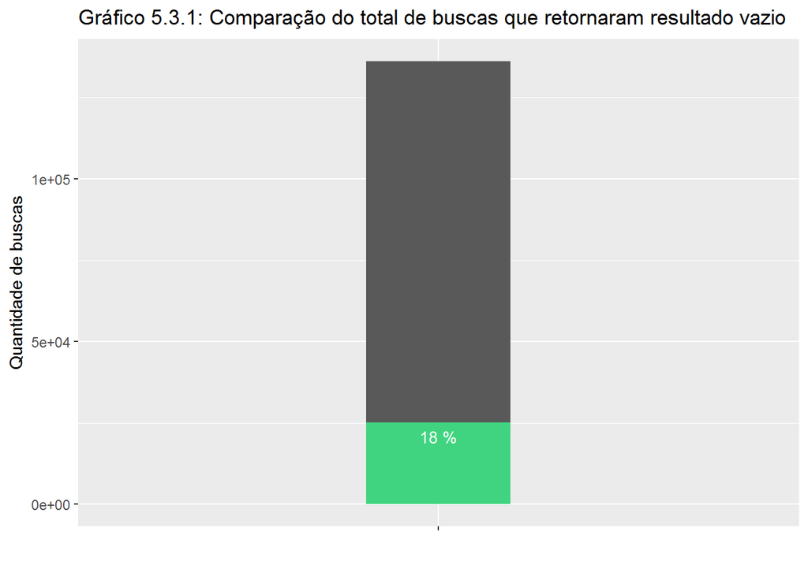

```r
total_sem_resultado <- buscas %>%
    filter(results == 0) %>%
    summarise(n_vazio = n())

total_com_resultado <- buscas %>%
    summarise(n_total = n())

merge(total_com_resultado, total_sem_resultado) %>%
    ggplot() +
    geom_col(aes(x = "", y = n_total), width = 0.2) +
    geom_col(aes(x = "", y = n_vazio), fill = "#41d480", width = 0.2) +
    geom_text(aes(x = "", y = n_vazio, label=paste(trunc((n_vazio/n_total)*100), "%")), vjust=1.6, color="white", size=3.5) +
    labs(x = "", y = "Quantidade de buscas",
         title = "Gráfico 5.3.1: Comparação do total de buscas que retornaram resultado vazio")
```

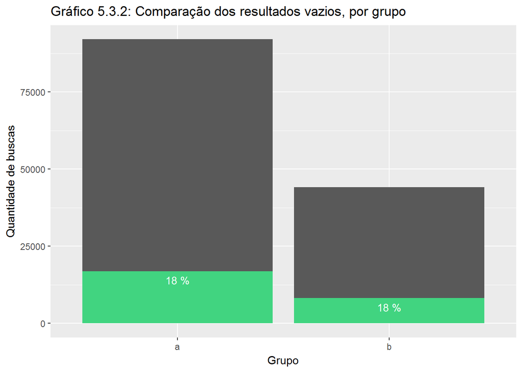

```r
total_com_resultado <- buscas %>%
    group_by(group) %>%
    summarise(n_total = n())

total_sem_resultado <- buscas %>%
    filter(results == 0) %>%
    group_by(group) %>%
    summarise(n_vazio = n())

merge(total_com_resultado, total_sem_resultado) %>%
    ggplot() +
    geom_col(aes(x = group, y = n_total)) +
    geom_col(aes(x = group, y = n_vazio), fill = "#41d480") +
    geom_text(aes(x = group, y = n_vazio, label=paste(trunc((n_vazio/n_total)*100), "%")), vjust=1.6, color="white", size=3.5) +
    labs(x = "Grupo", y = "Quantidade de buscas",
         title = "Gráfico 5.3.2: Comparação dos resultados vazios, por grupo")
```

Segue, abaixo, as análises com bootstrap.

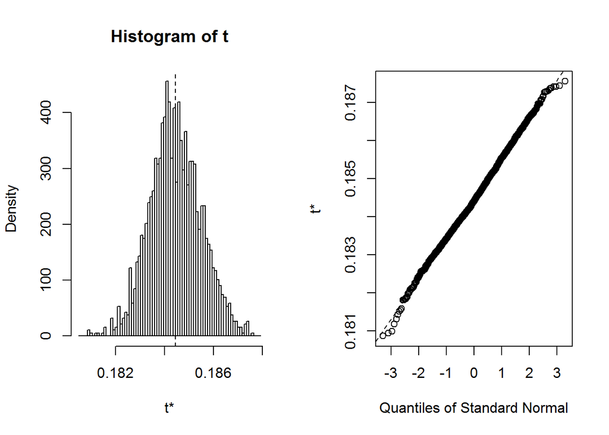

```r
amostra <- buscas

calcula_taxa_resultados <- function(dados, indices) {
    dados <- dados %>%
            slice(indices)

    total_sem_resultado <- dados %>%
                            filter(results == 0) %>%
                            summarise(total_buscas_vazias = n()) %>%
                            pull(total_buscas_vazias)

    total_de_buscas <- dados %>%
                        summarise(total_buscas = n()) %>%
                        pull(total_buscas)

    taxa_buscas_sem_resultado <- total_sem_resultado / total_de_buscas

    return(taxa_buscas_sem_resultado)
}

res.boot <- boot(data = amostra,
                 statistic = calcula_taxa_resultados,
                 R = 2000)
plot(res.boot)
```

```r
calcula_ci(res.boot)
```

```
## BOOTSTRAP CONFIDENCE INTERVAL CALCULATIONS
## Based on 2000 bootstrap replicates
##
## CALL :
## boot.ci(boot.out = distribuicao, conf = 0.95, type = "basic")
##
## Intervals :
## Level      Basic
## 95%   ( 0.1823,  0.1864 )
## Calculations and Intervals on Original Scale
```

Os resultados acima nos mostram que, no geral, a taxa de resultados zero é 18%, com um intervalo de confiança de 95% muito pequeno.

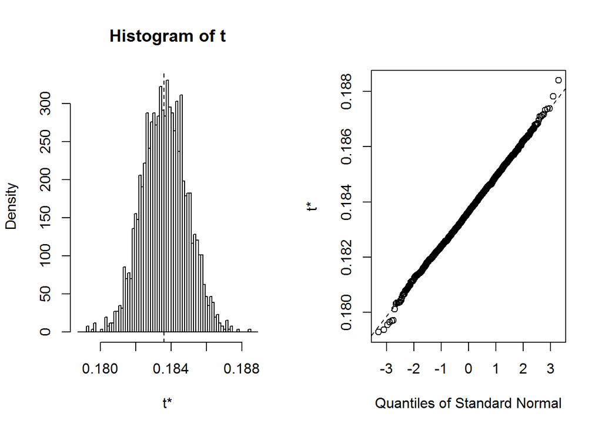

```r
amostra <- buscas

calcula_taxa_resultados <- function(dados, indices) {
    dados <- dados %>%
            slice(indices)

    buscas_sem_resultado <- dados %>%
                            filter(results == 0) %>%
                            group_by(group) %>%
                            summarise(total_buscas_vazias = n()) %>%
                            pull(total_buscas_vazias)

    total_de_buscas <- dados %>%
                        group_by(group) %>%
                        summarise(total_buscas = n()) %>%
                        pull(total_buscas)

    taxa_buscas_sem_resultado <- (buscas_sem_resultado[1] / total_de_buscas[1])
                                    - (buscas_sem_resultado[2] / total_de_buscas[2])

    return(taxa_buscas_sem_resultado)

}

res.boot <- boot(data = amostra,
                 statistic = calcula_taxa_resultados,
                 R = 2000)
plot(res.boot)
```

```r
calcula_ci(res.boot)
```

```
## BOOTSTRAP CONFIDENCE INTERVAL CALCULATIONS
## Based on 2000 bootstrap replicates
##
## CALL :
## boot.ci(boot.out = distribuicao, conf = 0.95, type = "basic")
##
## Intervals :
## Level      Basic
## 95%   ( 0.1811,  0.1859 )
## Calculations and Intervals on Original Scale
```

## 5. Conclusões

Neste relatório, respondemos às mesmas perguntas do laboratório anterior, porém com técnicas de bootstrap, para inferir com mais confiança os resultados de todos os usuários da Wikimedia. Além disso, os resultados coincidiram com os já encontrados.

## 6. Referências

¹ https://github.com/wikimedia-research/Discovery-Hiring-Analyst-2016 ² http://rpubs.com/veruskasantos/385180